# Human shields and civilian deaths

The effects of weakened IHL enforcement on the use and abuse of human shields

Macartan Humphreys (WZB)

2026-10-08

## Motivation

> Launching rockets or hiding weapons near civilians is reprehensible. You traumatize people by using weapons next to them. If you know that the other side is likely to return fire, you either intend that people be harmed for a public relations gain, or you’re at least indifferent to it. If you think that the other side won’t respond because of your proximity to civilians, you are using those people as human shields. […] But to argue that this absolves the other party from responsibility is to get both law and morality wrong

> Lieblich (2021)

## This project

A (formal) theoretical investigation into the strategic logic of the use of human shields, and the conditions that explain them

Particular interest is the role of **sanctions**, given the strategic considerations:

- IHL forbids the **use** of civilians as shields and also the **disregard** of shields: the (disproportionate) killing of protected persons that are employed as shields (Geneva Convention IV, Article 28; Additional Protocol I, Article 51(7)–(8) (Sandoz et al. 1987))
- The question is what those two prohibitions do to **who mingles** and **who dies**.

## Camouflage

> I was stationed […] with another twenty-five soldiers and about twenty Kamajors. […] We heard a lot of noise; people shouting, civilians, children, the sound of people walking and saw what I estimated to be more than 2,000 civilians carrying things on their heads and backs. Suddenly we saw an armed man in the crowd and said, who goes there. He refused to say anything and someone fired a shot and then the whole thing started. […] In the end I think many civilians were killed. […] And the civilians kept coming. They were so many and we just didn’t know who was among them.

ECOMOG soldier in Sierra Leone, quoted by Dufka (1999)

## Deterrence

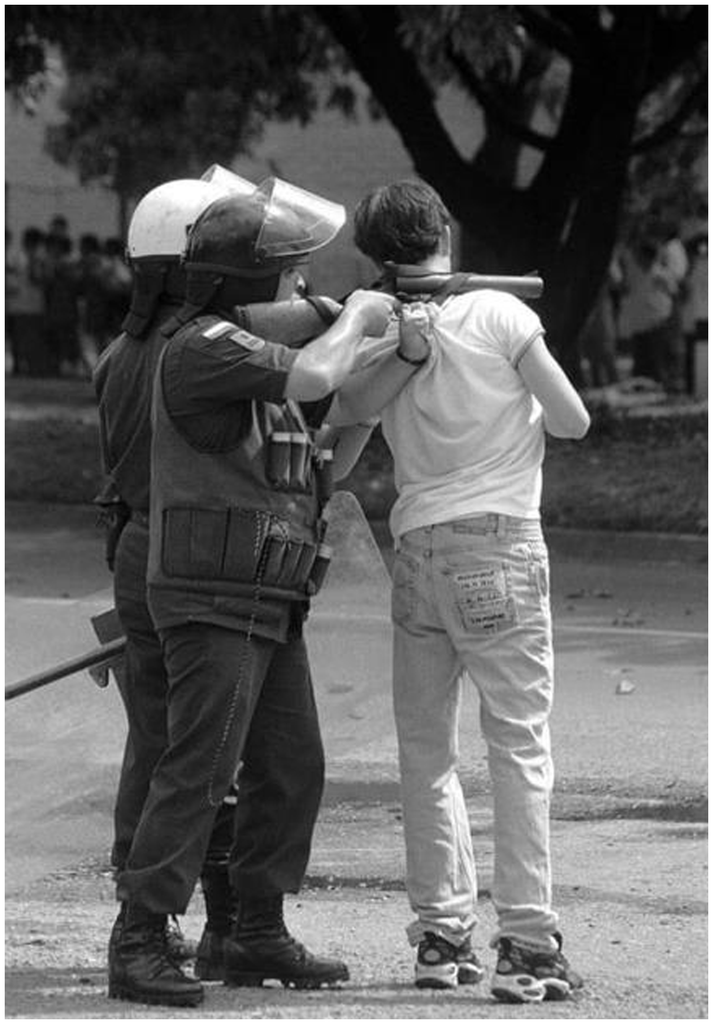

Jesús Abad Colorado, 1999. Colegio INEM, Medellín, Antioquia

Colombia: Sayed, *Leiden Journal of International Law*

## Deterrence

[figure not shown]

HRW: The armed groups say they are placing civilians in metal cages to deter indiscriminate government attacks on the area.

[Syria; Human Rights Watch, 2 November 2015](https://www.hrw.org/news/2015/11/02/syria-armed-groups-use-caged-hostages-deter-attacks) (Human Rights Watch 2015)

## Subtler forms

Proximate shields, coerced shields, volunteers (Gordon and Perugini 2020).

[BBC On This Day, 23 August 1990](http://news.bbc.co.uk/onthisday/hi/dates/stories/august/23/newsid_2512000/2512289.stm)

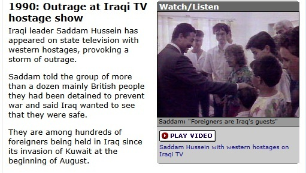

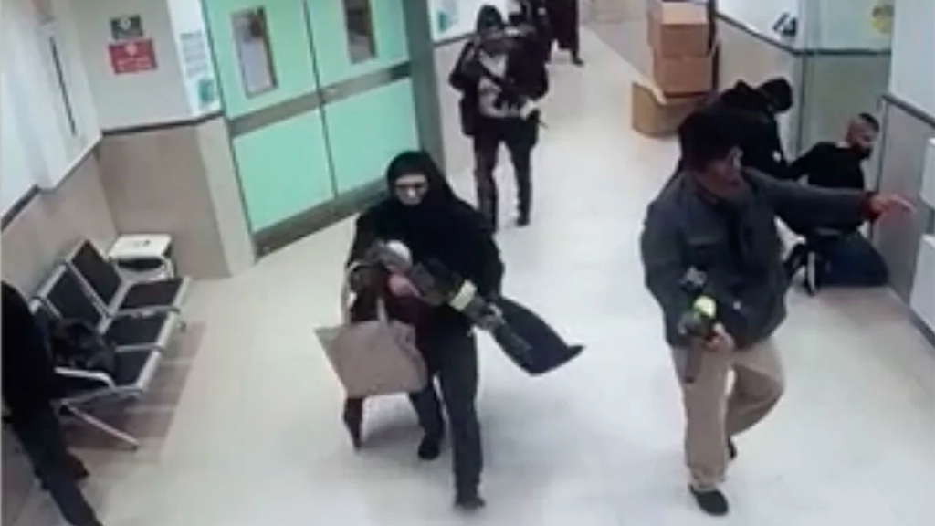

[Jenin hospital raid, 2024 (CNN)](https://edition.cnn.com/videos/world/2024/01/30/cctv-israeli-special-forces-kill-palestinian-militants-in-hospital-jenin-west-bank-cnntm-intl-ldn-vpx.cnn)

## Exposure and baiting

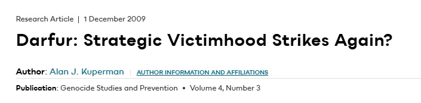

Rebels place their own civilians at risk in order to draw outside support.

[Alan J. Kuperman, *Genocide Studies and Prevention* 4(3), 2009](https://utppublishing.com/doi/10.3138/gsp.4.3.281) (Kuperman 2009)

## Varying autonomy

[Solomko, *Human shield*](https://en.wikipedia.org/wiki/Human_shield#/media/File:Human_shield_-_S._Solomko.jpg)

[figure not shown]

## Varying autonomy

[Solomko, *Human shield*](https://en.wikipedia.org/wiki/Human_shield#/media/File:Human_shield_-_S._Solomko.jpg)

[figure not shown]

[figure not shown]

[Ernie O’Malley and Sheila Humphreys](https://humphrysfamilytree.com/Humphrys/Struggle/7.jpg)

## Opposite timing

[figure not shown]

In cases in which shields are used against booby traps, the timing is opposite: the employer of the shield is the second mover.

[Natan Odenheimer, Bilal Shbair, and Patrick Kingsley, *The New York Times*, 14 October 2024](https://www.nytimes.com/2024/10/14/world/middleeast/israel-gaza-military-human-shields.html) (Odenheimer et al. 2024)

## What counts

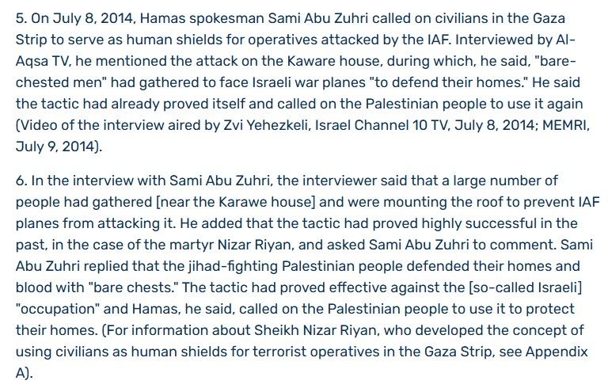

What counts is disputed. Civic resistance or human shields?

[Ministry of Foreign Affairs, *Hamas again uses Gazan civilians as human shields*, 11 July 2014](https://www.gov.il/en/pages/hamas-again-uses-gazan-civilians-as-human-shields) (Ministry of Foreign Affairs 2014)

## Varying scales

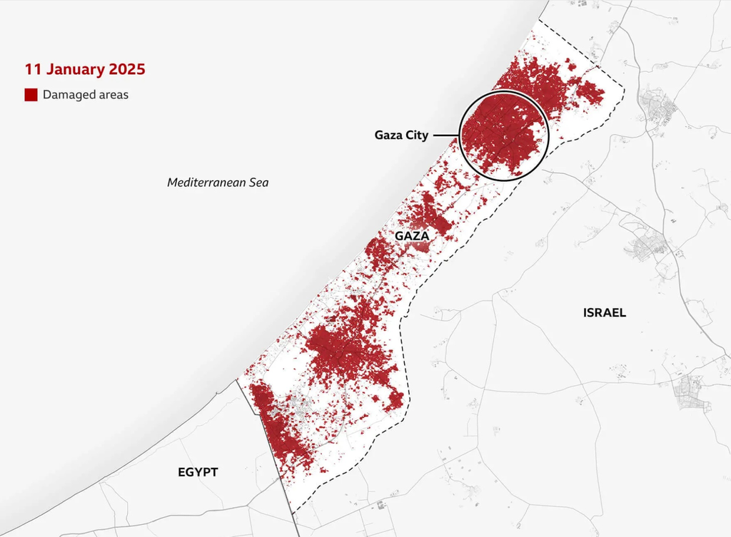

> “What could change the equation was a great act, and without a doubt, it was known that the reaction to this great act would be big,” Mr. al-Hayya said. NYT (Hubbard and Abi-Habib 2023)

(Though note that this statement does not distinguish intent from byproduct.)

## Normative clarifications

I am not dealing directly with the discursive debates on the term, important as they are.

> The discursive construction of civilians as human shields supposedly allows a slackening of the rules of proportionality and distinction and legitimises a higher level of collateral damage by transferring responsibility for civilian losses to enemy forces and sometimes even to the people themselves if they are presumed to have consented to be used as shields. Douillard (2021)
- **The term human shields is sometimes used to suggest that civilians are not protected** (Sayed 2024).
  - Law seems quite explicit: Using civilians as shields does not remove their protection.
  - The *consequences* of this debate can be handled in this framework.

## Other normative dimensions

- **The model presupposes that every side puts a nonnegative value on civilian life.**
  - That is not necessarily true.
- **The model presupposes that every side benefits from audiences believing that it cares about civilian life.**
  - That is not necessarily true. Being seen to care can be treated as a weakness.

# A simple game

- We imagine a world in which a **rebel group**, *R* decides whether to mingle among civilians (or remain in ‘the bush’)
- A **state**, *S*, decides whether to attack despite the predictable civilian casualties

## Bare bones logic

Simplest model focused on **zero-sum** components and penalties; abstracting from reputational, value based, and military considerations.

`Player 1` (rebels) chooses whether to enter.

- If they stay out, both get 0.
- If they enter, Player 2 (the state) must transfer $1 one way or the other.

`Player 2` (state) chooses:

- Fire: take $1 from 1, but pay $\pi_2$ back to 1.
- Hold fire: give $1 to 1.

**IHL**:

- $\pi_1$: the sanction on using a shield.
- $\pi_2$ is the sanction on disregarding shields.

## The game tree

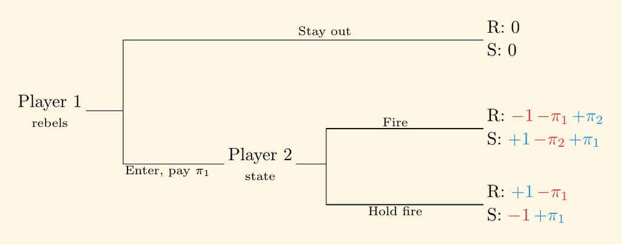

The state will fire iff $\pi_2 < 2$ (prefers $1-\pi_2$ to $-1$).

Given this, rebels will enter iff that reply beats 0: iff $\pi_2 > 1+\pi_1$ when the state fires, and iff $1-\pi_1>0$ when it holds fire.

## Analysis:

| Path | Later name | $\pi_2$ |
| --- | --- | --- |
| Stay out | Mingling deterred | **Low.** Entering would be met by fire, so rebels stay out. |
| Enter, then fire | Asymmetric exposure (entrapment) | **Intermediate.** The state still fires; rebels enter and collect $\pi_2$. |
| Enter, then hold fire | Hiding (brinkmanship) | **High.** The state will not fire. Rebels enter. |

Raising the sanction on fire can move the path from *nobody enters* to *enter and get shot*.

## Sanction effects are ambiguous

In this game, a higher $\pi_2$ can **raise** the chance of expropriation / violence.

The remedy on this tree is $\pi_1$. A sanction on entry of $\pi_1 \ge 1$ shuts the entrapment outcome.

# Full model

## What gets added

**Varying motives**: Each side is a low type or a high type. Low types do not pay for a civilian death. High types do.

The two sides know the pair of types. Civilians do not. Civilians update from the actions they see.

**Setting**

- $k$: rebel identifiability. Higher $k$ is a more discriminating strike.
- $q$: death risk in the bush.
- $\pi_S$: state-side sanction, paid as $\pi_S/k$ when the state fires on that crowd.
- $\pi_R$: rebel-side sanction, paid when rebels mingle.

The net prize from firing is $\tau(k)=k-\pi_S/k$.

## Eight ways the game can end

Under a mild assumption on beliefs we have eight strict pure equilibria.

- Boxed cells are on the path.
- $0$ is stay out or hold fire.
- $1$ is mingle or fire.

These each provide evidence on **explanations** for actions.

| Profile | $r_L$ vs L | $r_L$ vs H | $r_H$ vs L | $r_H$ vs H | $s_L$ $r=0$ | $s_L$ $r=1$ | $s_H$ $r=0$ | $s_H$ $r=1$ |
| --- | --- | --- | --- | --- | --- | --- | --- | --- |
| Never mingle | 0 | 0 | 0 | 0 | 0 | 0 | 0 | 0 |
| Mingling deterred | 0 | 0 | 0 | 0 | 0 | 1 | 0 | 0 |
| Hiding | 1 | 1 | 1 | 1 | 0 | 0 | 0 | 0 |
| Safe mingling | 0 | 1 | 0 | 1 | 0 | 1 | 0 | 0 |
| Exposure | 1 | 1 | 1 | 1 | 0 | 1 | 0 | 0 |
| Joint exposure | 1 | 0 | 0 | 0 | 0 | 1 | 0 | 0 |
| Asymmetric exposure | 1 | 1 | 0 | 1 | 0 | 1 | 0 | 0 |
| Bait | 1 | 0 | 1 | 0 | 0 | 1 | 0 | 0 |

$r$: mingle given the state type. $s$: fire given entry. Box: on the path.

## Why enter a crowd?

Four distinct reasons.

- **Military expediency.** The crowd is safer than the bush, even if attacked.
- **Brinkmanship.** They enter because they expect the state *not* to shoot (Schelling 1970).
- **Revelation.** They enter to move civilians’ beliefs about who values civilian life.
- **Entrapment.** They enter because an attack by the state will trigger a sanction (that benfits rebels).

These might multiple determine or over determine the outcomes

## Why stay out?

A similar accounting on types who do not mingle. What explains it when rebels do **not** mingle?

- **Military expediency.** The bush may be safer than a crowd under fire.
- **Signalling through restraint.** Entering may make the state look better (if the state does not react), or make the rebels look worse.
- **Penalty avoidance.** Entering triggers the rebel-side sanction $\pi_R$.

We want to assess when these different motivations *explain* outcomes: conscious that there may be multiple explanations at once.

## Explanations for entry, given entry

| Profile | Rebel | State | Violence | Expediency | Brinkmanship | Entrapment | Revelation | Multiple |
| --- | --- | --- | --- | --- | --- | --- | --- | --- |
| Hiding | $L$ | Either |  | $\checkmark$ | C1 |  |  | Sometimes |
|  | $H$ | Either |  | $\checkmark$ | C2 |  |  | Sometimes |
| Safe mingling | $L$ | $H$ |  | $\checkmark$ | $\checkmark$ |  |  | Always |
|  | $H$ | $H$ |  | $\checkmark$ | $\checkmark$ |  |  | Always |
| Exposure | $L$ | $H$ |  | $\checkmark$ | C3 |  |  | Sometimes |
|  | $H$ | $H$ |  | $\checkmark$ | $\checkmark$ |  |  | Always |
|  | $L$ | $L$ | $\times$ |  |  |  | C4 | Never |
|  | $H$ | $L$ | $\times$ | C5 |  | C12 | $\checkmark$ | Sometimes |
| Joint exposure | $L$ | $L$ | $\times$ | C7 |  | C13 | C6 | Sometimes |
| Asymmetric | $L$ | $H$ |  | $\checkmark$ | C8 |  |  | Sometimes |
|  | $H$ | $H$ |  | $\checkmark$ | $\checkmark$ |  |  | Always |
|  | $L$ | $L$ | $\times$ | C9 |  | C14 |  | Sometimes |
| Bait | $L$ | $L$ | $\times$ |  |  |  | C10 | Never |
|  | $H$ | $L$ | $\times$ | C11 |  | C15 | $\checkmark$ | Sometimes |

On-path entries and when each motive is decisive. Blank: nowhere on the row. Tick: the whole strict interior. C: a subset. x: the state fires. $L$ and $H$ are low and high types. Multiple: two or more together, on the whole interior, on a subset, or nowhere.

## Explanations for non-entry, given non-entry

| Profile | Rebel | State | Violence risk | Expediency | Avoid $\pi_R$ | State rev. | Rebel rev. | Multiple |
| --- | --- | --- | --- | --- | --- | --- | --- | --- |
| Never mingle | $L$ | Either |  |  | N15 | N1 | N2 | Sometimes |
|  | $H$ | Either |  |  | N15 | N1 | N2 | Sometimes |
| Mingling deterred | $L$ | $H$ |  |  | N15 | N1 | N2 | Sometimes |
|  | $H$ | $H$ |  |  | N15 | N1 | N2 | Sometimes |
|  | $L$ | $L$ | $\times$ | N3 | N16 |  | N4 | Sometimes |
|  | $H$ | $L$ | $\times$ | N5 | N17 |  | N6 | Sometimes |
| Safe mingling | $L$ | $L$ | $\times$ | N7 | N18 |  | N8 | Sometimes |
|  | $H$ | $L$ | $\times$ | N9 | N19 |  |  | Sometimes |
| Joint exposure | $L$ | $H$ |  |  | N20 | N10 | N11 | Sometimes |
|  | $H$ | $H$ |  |  | N20 | N10 | N11 | Sometimes |
|  | $H$ | $L$ | $\times$ | N12 | N21 |  | N13 | Sometimes |
| Asymmetric | $H$ | $L$ | $\times$ | N14 |  |  |  | Never |
| Bait | $L$ | $H$ |  |  | N22 |  | $\checkmark$ | Sometimes |
|  | $H$ | $H$ |  |  | N22 |  | $\checkmark$ | Sometimes |

On-path stay-outs and when each motive is decisive. Blank: nowhere on the row. Tick: the whole strict interior. N: a subset. Violence risk is an x when the reply to entry is fire. No on-path violence on these rows.

## The effects of changes in background condtions

At the illustrative prior. Creates: a rise can bring the profile in. Destroys: a rise can push it out. Either: both.

| Profile | $k$ rebel identifiability | $q$ bush risk | $\pi_S$ state sanction | $\pi_R$ rebel sanction | $\beta_S$ state weight | $\beta_R$ rebel weight |
| --- | --- | --- | --- | --- | --- | --- |
| Never mingle | Destroys | Destroys | Creates | Creates | Creates | Creates |
| Mingling deterred | Creates | Destroys | Destroys | Creates | Destroys | Creates |
| Hiding | Destroys | Creates | Creates | Destroys | Creates | Destroys |
| Safe mingling | Creates | Either | Destroys | Either | Destroys | Either |
| Exposure | Either | Creates | Either | Destroys | Destroys | Either |
| Joint exposure | Either | Either | Either | Either | Destroys | Either |
| Asymmetric exposure | Either | Creates | Either | Destroys | Destroys | Destroys |
| Bait | Either | Either | Either | Either | Destroys | Creates |

On this prior $\gamma<0$, so a higher $\beta_R$ expands mingling deterred.

# Ambiguous effects a state-side sanction persist

## Two effects of a state-side sanction

Raising $\pi_S$ does two opposite things.

1. **Disciplines the state.** The prize $\tau(k)$ falls. The low state is less willing to fire.
2. **Pays the rebels.** If they are shot, they collect $\pi_S/k$. Walking into fire gets cheaper.

Either effect can dominate. Deaths can rise when the sanction rises. They can fall when it falls.

**So as before**: ambiguous effects of $\pi_S$.

## Deaths rise, then fall

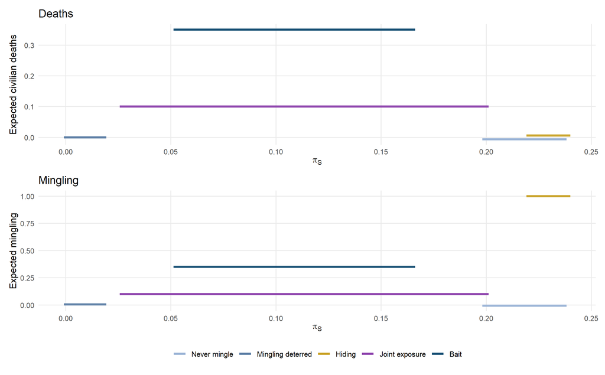

Fix $k=0.50$, $q=0.55$. As $\pi_S$ rises: no deaths, then joint exposure at $p_{LL}=0.10$, then none again.

Bait, if the off-path reading that supports it is used, sits at $\Pr(S=L)=0.35$ on a nested interval.

## A sanction on mingling is cleaner

Raising $\pi_R$ shifts every rebel threshold up by $\pi_R$. Staying out gets easier. Entering gets harder.

It does not change the state’s prize $\tau(k)$.

It does not create exposure. It can move bait’s window up in bush risk, so bait may appear at a higher $q$ as it disappears at a lower one.

To shut the entrapment logic on the simple tree, $\pi_1$ had to be large enough. The same role is $\pi_R$ here.

# Signalling rationales have a similar dynamic

## Exposure rationales more likely when *rebels* care more about reputation

- Entering to reveal information requires ex ante uncertainty about motivations
- **Revelation fire needs unequal weights and bad outside options.** Rebels draw fire to reveal the state only when they weight civilians’ beliefs enough, and only when $q$ is high. Equal weights empty exposure, bait, and joint exposure.
- **Deaths can remain without a revelation motive.** Hiding, deterrence, safe mingling, and asymmetric exposure survive equal weights. Deaths then come from expediency, from entrapment if $\pi_S>0$, or from low rebels who walk into fire because the bush is worse.

# Wrap up

## High level takeaways

- It can make sense (strategically not morally) for fighters to (deliberately) exposure citizens to risk in order to draw fire and expose the motivations of attackers.This is true *even if* in doing so they reveal their own indifference to citizens suffering.
- Sanctions and revelation logics each have ambiguous effects. Deaths are not monotone in the sanction meant to protect civilians. A sanction on fire is a transfer to the side that entered.
- There are multiple reasons for mingling and they can operate simultaneously.

## Responses?

- **Information helps.** Strategies whose point is to costly expose the other side generally require uncertainty.
- **Where $\pi_S$ starts matters.** If sanctions against firing on a crowd starts high, weakening it can raise deaths: we rebels bait states and states take the bait. If $\pi_S$ is already modest, a further weakening can cut deaths: entry stops paying enough.
- **Do not let $\pi_S$ and $\pi_R$ drift apart.** Entrapment is most attractive when the transfer from a firing state is large relative to the cost of mingling. A sanction on using shields has no second channel. It is what shuts that path.
- **Conditional sanctions** Should IHL action depend on motivations for shields? as it does for attacks?

**Critical Caveat**: Everything here presupposes **strategic** actors. If, as plausible, *R* is acting nonstrategically (not conditioning entry on $\pi_S$) then the case for higher $\pi_S$ is unambiguous.

# Extra slides

## Protected status

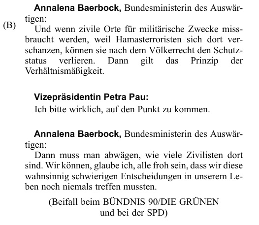

Baerbock seemingly supporting attacks on hospitals while trying to maintain the principle of proportionality.

And when civilian sites are misused for military purposes, because Hamas terrorists entrench themselves there, they can lose their protected status under international law. Then the principle of proportionality applies. One must then weigh how many civilians are there. I think we can all be glad that we have never yet had to make these incredibly difficult decisions in our lives.

## Line of fire

[figure not shown]

[Ministry of Foreign Affairs, *Hamas again uses Gazan civilians as human shields*, 11 July 2014](https://www.gov.il/en/pages/hamas-again-uses-gazan-civilians-as-human-shields) (Ministry of Foreign Affairs 2014)

## Human dome

[figure not shown]

[Neve Gordon and Nicola Perugini, *Human Shields and the Location of Agency*, TWAILR, 2021](https://twailr.com/human-shields-and-the-location-of-agency/) (Gordon and Perugini 2021)

## Exposure rationales more likely when rebels care more about reputation than states do

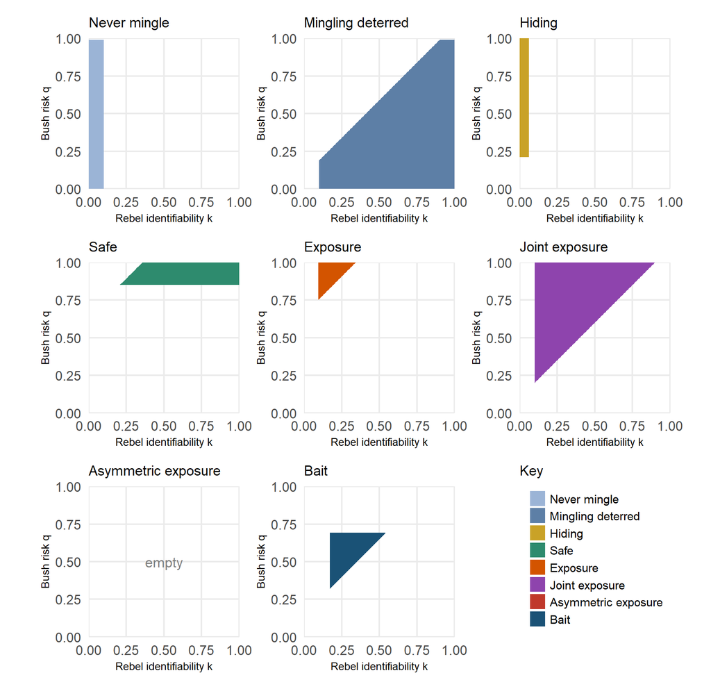

Illustrative prior. $\beta_S=0.1$, $\beta_R=0.9$, no sanctions.

- Stay-out (never, deterred) needs small $q$. Hiding, exposure, and asymmetric exposure need large $q$.
- Safe mingling, joint exposure, and bait sit between a floor and a ceiling on $q$.
- Never and hiding need small $\tau(k)$: the low state holds fire. Higher rebel identifiability raises $\tau$ and can shut those profiles.
- The six fire profiles need large $\tau$. In exposure, joint, asymmetric, and bait, a larger prize also raises the $q$ at which rebels mingle.

## Compare with when the two sides care equally

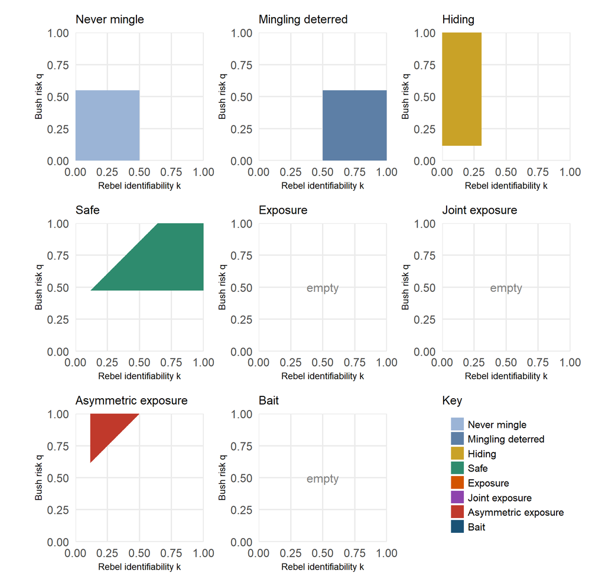

$\beta_S=\beta_R=0.5$.

- Exposure, joint exposure, and bait are empty. Drawing fire to reveal the state needs rebels to weight beliefs more than the state does.
- Asymmetric exposure occupies high $q$: low rebels accept fire because the bush is worse, not to move beliefs.
- Stay-out still wants small $q$. Hiding still wants low identifiability.
- A band of $(k,q)$ has no strict profile.

## References

Douillard, Romain. 2021. *Human Shields in Contemporary Conflicts*. Research Paper No. 112. Institut de recherche stratégique de l’École militaire. https://www.irsem.fr/en/publications/human-shields-in-contemporary-conflicts.

Dufka, Corinne. 1999. *Getting Away with Murder, Mutilation, and Rape: New Testimony from Sierra Leone*. Human Rights Watch. https://www.refworld.org/reference/countryrep/hrw/1999/en/39219.

Gordon, Neve, and Nicola Perugini. 2020. *Human Shields: A History of People in the Line of Fire*. University of California Press. https://www.ucpress.edu/books/human-shields/hardcover.

Gordon, Neve, and Nicola Perugini. 2021. “Human Shields and the Location of Agency.” *TWAIL Review*. https://twailr.com/human-shields-and-the-location-of-agency/.

Hubbard, Ben, and Maria Abi-Habib. 2023. “Behind Hamas’s Bloody Gambit to Create a ‘Permanent’ State of War.” *The New York Times*, November. https://www.nytimes.com/2023/11/08/world/middleeast/hamas-israel-gaza-war.html.

Human Rights Watch. 2015. *Syria: Armed Groups Use Caged Hostages to Deter Attacks*. News release. https://www.hrw.org/news/2015/11/02/syria-armed-groups-use-caged-hostages-deter-attacks.

Kuperman, Alan J. 2009. “Darfur: Strategic Victimhood Strikes Again?” *Genocide Studies and Prevention* 4 (3): 281–303. https://doi.org/10.3138/gsp.4.3.281.

Lieblich, Eliav. 2021. “Dispatch from Israel on Human Shields: What i Should’ve Said to a Dad on the Playground.” *Just Security*, May. https://www.justsecurity.org/76220/dispatch-from-israel-on-human-shields-what-i-shouldve-said-to-a-dad-on-the-playground/.

Ministry of Foreign Affairs. 2014. *Hamas Again Uses Gazan Civilians as Human Shields*. Information. https://www.gov.il/en/pages/hamas-again-uses-gazan-civilians-as-human-shields.

Odenheimer, Natan, Bilal Shbair, and Patrick Kingsley. 2024. “How Israel’s Army Uses Palestinians as Human Shields in Gaza.” *The New York Times*, October. https://www.nytimes.com/2024/10/14/world/middleeast/israel-gaza-military-human-shields.html.

Sandoz, Yves, Christophe Swinarski, and Bruno Zimmermann. 1987. *Commentary on the Additional Protocols of 8 June 1977 to the Geneva Conventions of 12 August 1949*. International Committee of the Red Cross; Martinus Nijhoff. https://www.icrc.org/en/publication/0421-commentary-additional-protocols-8-june-1977-geneva-conventions-12-august-1949.

Sayed, Abdelghany. 2024. “What We Talk about When We Talk about ‘Human Shields’: Reading International Law Through Images.” *Leiden Journal of International Law* 37 (4): 773–800. https://doi.org/10.1017/S0922156524000190.

Schelling, Thomas C. 1970. “The Diplomacy of Violence.” In *Theories of Peace and Security: A Reader in Contemporary Strategic Thought*. Springer.